# Car Prices

## Background

A study was done to find the overall decline of prices of several cars by finding car prices of varying cars over the years. It’s often wondered how one can maintain the value of their car and how much is therir car actually worth. We obviously know some cars are worth more than others. I raised the question; what is the overall decline of the Chevrolet Corvette Coupe value compared to the Chevrolet Corvette Convertible?

I have used the following model to exhibit our test:

The hypothesis is as follows:
$$H_0: \beta_j = 0$$

$$H_a: \beta_j \neq 0$$

## Data

This data table shows the decrease in values of the Corvette model. It is taken originally from a larger list of other car values, but for the sake of this test it has been truncated.

```r
datatable(Corve,options = list(lengthMenu=c(5,10,20)))
```

|  | Price | Mileage | Make | Model | Trim | Type | Cylinder | Liter | Doors | Cruise | Sound | Leather |
| --- | --- | --- | --- | --- | --- | --- | --- | --- | --- | --- | --- | --- |
| 341 | 46732.60603 | 3625 | Chevrolet | Corvette | Conv 2D | Convertible | 8 | 6 | 2 | 1 | 1 | 1 |
| 342 | 47065.20991 | 5239 | Chevrolet | Corvette | Conv 2D | Convertible | 8 | 6 | 2 | 1 | 1 | 1 |
| 343 | 44749.68679 | 12115 | Chevrolet | Corvette | Conv 2D | Convertible | 8 | 6 | 2 | 1 | 0 | 1 |
| 344 | 42773.02839 | 14546 | Chevrolet | Corvette | Conv 2D | Convertible | 8 | 6 | 2 | 1 | 1 | 1 |
| 345 | 41371.37927 | 20000 | Chevrolet | Corvette | Conv 2D | Convertible | 8 | 6 | 2 | 1 | 0 | 1 |
| 346 | 39547.5879 | 23826 | Chevrolet | Corvette | Conv 2D | Convertible | 8 | 6 | 2 | 1 | 1 | 1 |
| 347 | 39691.7274 | 25169 | Chevrolet | Corvette | Conv 2D | Convertible | 8 | 6 | 2 | 1 | 1 | 1 |
| 348 | 38824.86909 | 25960 | Chevrolet | Corvette | Conv 2D | Convertible | 8 | 6 | 2 | 1 | 0 | 1 |
| 349 | 36970.89805 | 30502 | Chevrolet | Corvette | Conv 2D | Convertible | 8 | 6 | 2 | 1 | 1 | 1 |
| 350 | 37288.93674 | 32039 | Chevrolet | Corvette | Conv 2D | Convertible | 8 | 6 | 2 | 1 | 1 | 1 |

[output cut: 10 more lines]

## Analysis

To be sure we have normality within the data we have produced the following plots.

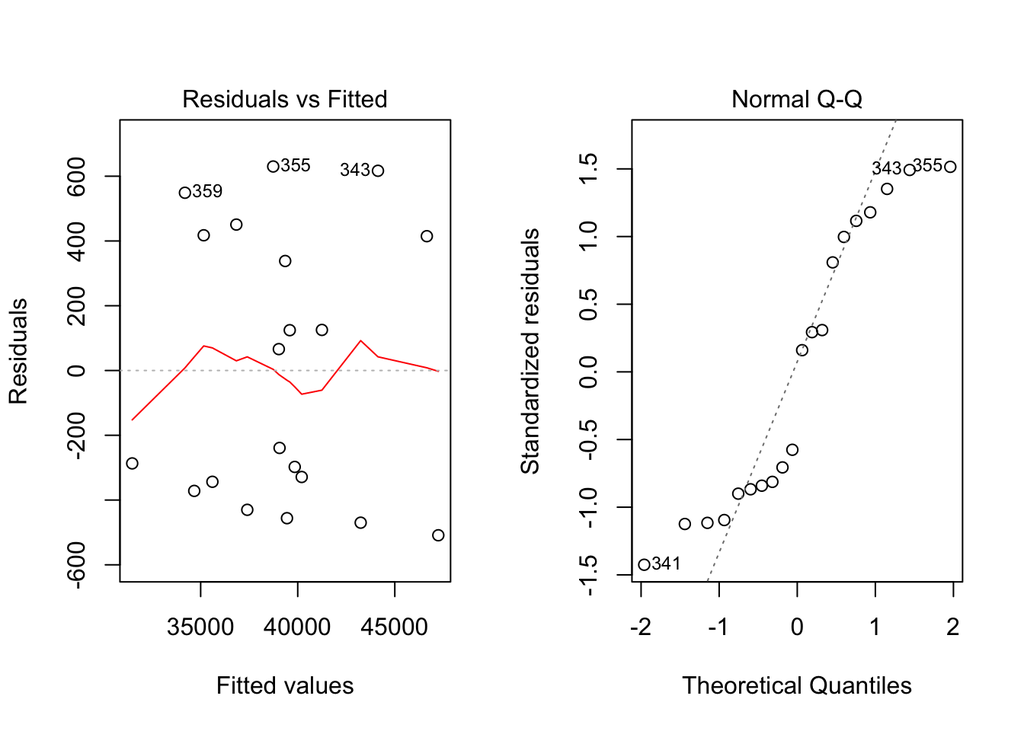

```r
par(mfrow=c(1,2))
plot(lmcor, which=1:2)
```

From these plots we understand that the normality is questionable. The QQ plot showed that the error terms being normally distributed are debatable. The Residuals and Fitted plot shows that there is a regression and the variance of terms is constant over all x values. For now I will disregard these normality notes and carry on with they study, but please note that the plots showed questionable normality.

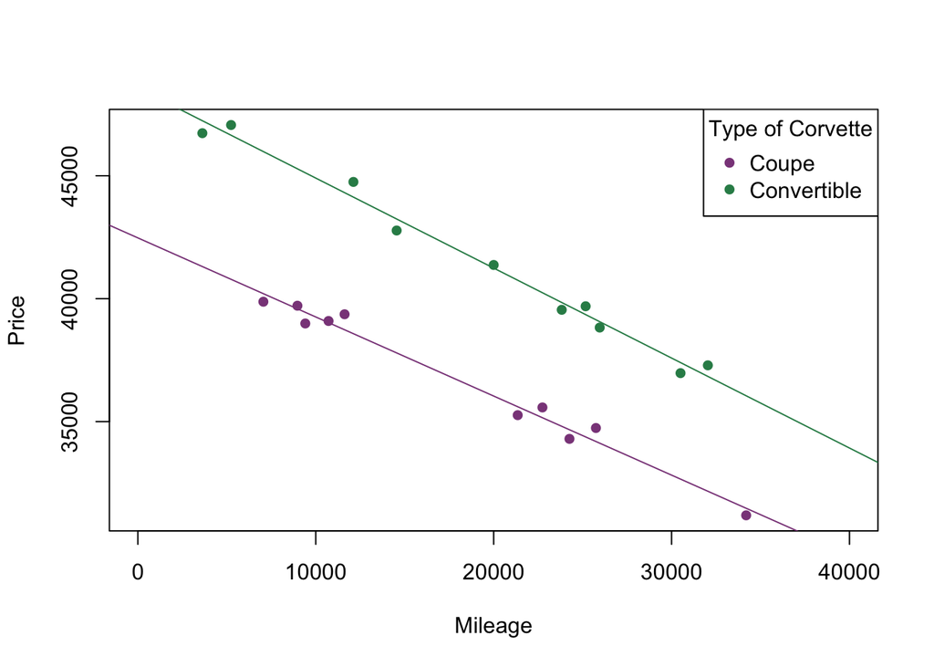

```r
palette(c('orchid4', 'seagreen'))
Corve<-subset(CarPrices, Model == 'Corvette')
lmcor<-lm(Price~Mileage+Trim+Mileage:Trim, data=Corve)
plot(Price~Mileage, data=Corve, col=Trim, pch=16, xlim=c(0,40000))
legend('topright', legend=c('Coupe', 'Convertible'), pch=16, col=palette(), title='Type of Corvette')
b<-lmcor$coefficients
abline(b[1], b[2], col=palette()[2])
abline(b[1]+b[3], b[2]+b[4], col=palette()[1])
```

Through the plot above we find the decline of the prices of the Corvette displayed. Note the following coefficients as representatives of this plot below.

```r
pander(lmcor)
```

Fitting linear model: Price ~ Mileage + Trim + Mileage:Trim

|  | Estimate | Std. Error | t value | Pr(>\|t\|) |
| --- | --- | --- | --- | --- |
| **(Intercept)** | 48569 | 322 | 150.8 | 1.17e-26 |
| **Mileage** | -0.3661 | 0.01496 | -24.47 | 4.189e-14 |
| **TrimCoupe 2D** | -6094 | 454.3 | -13.42 | 4.024e-10 |
| **Mileage:TrimCoupe 2D** | 0.04438 | 0.02213 | 2.006 | 0.06212 |

## Interpretation

There is sufficient Evidence to conclude that the first 3 coefficients are not equal to zero. The p-values of the t-tests are significant for the coefficients of the y intercept, the slope, and the change in y intercept for the second group. However, there is not sufficient evidence to conclude that the interaction of the second slope from the first slope is significantly different.

Again, please keep in mind the lack of normality of the plots, as this could’ve effected the significance of the data.